# Pandas Notes

## Basic Concepts

```python
import pandas as pd
import numpy as np
import matplotlib.pyplot as plt
```

pd.Series is like a list in Python. It represents a column in a DataFrame.

```python
pd.Series(['San Francisco', 'San Jose', 'Sacramento'])
```

```
0    San Francisco
1         San Jose
2       Sacramento
dtype: object
```

pd.DataFrame is like a table.

```python
city_names = pd.Series(['San Francisco', 'San Jose', 'Sacramento'])
population = pd.Series([852469, 1015785, 485199])

pd.DataFrame({ 'City name': city_names, 'Population': population })
```

|  | City name | Population |
| --- | --- | --- |
| 0 | San Francisco | 852469 |
| 1 | San Jose | 1015785 |
| 2 | Sacramento | 485199 |

Use pop() to remove the column you do not need from a DataFrame.

```python
df = pd.DataFrame({ 'City name': city_names, 'Population': population })
print(df)

print()
df.pop('Population')
print(df)
```

```
       City name  Population
0  San Francisco      852469
1       San Jose     1015785
2     Sacramento      485199

       City name
0  San Francisco
1       San Jose
2     Sacramento
```

```python
california_housing_dataframe = pd.read_csv("https://storage.googleapis.com/mledu-datasets/california_housing_train.csv", sep=",")
california_housing_dataframe.describe()
```

|  | longitude | latitude | housing_median_age | total_rooms | total_bedrooms | population | households | median_income | median_house_value |
| --- | --- | --- | --- | --- | --- | --- | --- | --- | --- |
| count | 17000.000000 | 17000.000000 | 17000.000000 | 17000.000000 | 17000.000000 | 17000.000000 | 17000.000000 | 17000.000000 | 17000.000000 |
| mean | -119.562108 | 35.625225 | 28.589353 | 2643.664412 | 539.410824 | 1429.573941 | 501.221941 | 3.883578 | 207300.912353 |
| std | 2.005166 | 2.137340 | 12.586937 | 2179.947071 | 421.499452 | 1147.852959 | 384.520841 | 1.908157 | 115983.764387 |
| min | -124.350000 | 32.540000 | 1.000000 | 2.000000 | 1.000000 | 3.000000 | 1.000000 | 0.499900 | 14999.000000 |
| 25% | -121.790000 | 33.930000 | 18.000000 | 1462.000000 | 297.000000 | 790.000000 | 282.000000 | 2.566375 | 119400.000000 |
| 50% | -118.490000 | 34.250000 | 29.000000 | 2127.000000 | 434.000000 | 1167.000000 | 409.000000 | 3.544600 | 180400.000000 |
| 75% | -118.000000 | 37.720000 | 37.000000 | 3151.250000 | 648.250000 | 1721.000000 | 605.250000 | 4.767000 | 265000.000000 |
| max | -114.310000 | 41.950000 | 52.000000 | 37937.000000 | 6445.000000 | 35682.000000 | 6082.000000 | 15.000100 | 500001.000000 |

Use head() and tail() to print some examples.

```python
california_housing_dataframe.head()
```

|  | longitude | latitude | housing_median_age | total_rooms | total_bedrooms | population | households | median_income | median_house_value |
| --- | --- | --- | --- | --- | --- | --- | --- | --- | --- |
| 0 | -114.31 | 34.19 | 15.0 | 5612.0 | 1283.0 | 1015.0 | 472.0 | 1.4936 | 66900.0 |
| 1 | -114.47 | 34.40 | 19.0 | 7650.0 | 1901.0 | 1129.0 | 463.0 | 1.8200 | 80100.0 |
| 2 | -114.56 | 33.69 | 17.0 | 720.0 | 174.0 | 333.0 | 117.0 | 1.6509 | 85700.0 |
| 3 | -114.57 | 33.64 | 14.0 | 1501.0 | 337.0 | 515.0 | 226.0 | 3.1917 | 73400.0 |
| 4 | -114.57 | 33.57 | 20.0 | 1454.0 | 326.0 | 624.0 | 262.0 | 1.9250 | 65500.0 |

```python
california_housing_dataframe.tail()
```

|  | longitude | latitude | housing_median_age | total_rooms | total_bedrooms | population | households | median_income | median_house_value |
| --- | --- | --- | --- | --- | --- | --- | --- | --- | --- |
| 16995 | -124.26 | 40.58 | 52.0 | 2217.0 | 394.0 | 907.0 | 369.0 | 2.3571 | 111400.0 |
| 16996 | -124.27 | 40.69 | 36.0 | 2349.0 | 528.0 | 1194.0 | 465.0 | 2.5179 | 79000.0 |
| 16997 | -124.30 | 41.84 | 17.0 | 2677.0 | 531.0 | 1244.0 | 456.0 | 3.0313 | 103600.0 |
| 16998 | -124.30 | 41.80 | 19.0 | 2672.0 | 552.0 | 1298.0 | 478.0 | 1.9797 | 85800.0 |
| 16999 | -124.35 | 40.54 | 52.0 | 1820.0 | 300.0 | 806.0 | 270.0 | 3.0147 | 94600.0 |

Use hist() to graph your data. It let you quickly study the distribution of values in a column.

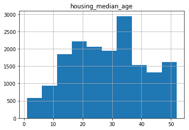

```python
california_housing_dataframe.hist('housing_median_age')
plt.show()
```

## Accessing Data

list/dict operatons.

```python
cities = pd.DataFrame({ 'City name': city_names, 'Population': population })
print(type(cities['City name']))
cities['City name']
```

```
<class 'pandas.core.series.Series'>
```

```
0    San Francisco
1         San Jose
2       Sacramento
Name: City name, dtype: object
```

```python
print(type(cities['City name'][1]))
cities['City name'][1]
```

```
<class 'str'>
```

```
'San Jose'
```

```python
print(type(cities['Population'][1]))
cities['Population'][1]
```

```
<class 'numpy.int64'>
```

```
1015785
```

```python
cities[0:2]
```

|  | City name | Population |
| --- | --- | --- |
| 0 | San Francisco | 852469 |
| 1 | San Jose | 1015785 |

```python
population / 1000
```

```
0     852.469
1    1015.785
2     485.199
dtype: float64
```

```python
population.apply(lambda x: x > 1000000)
```

```
0    False
1     True
2    False
dtype: bool
```

```python
population
```

```
0     852469
1    1015785
2     485199
dtype: int64
```

```python
population.apply(lambda x: x + 1000000)
```

```
0    1852469
1    2015785
2    1485199
dtype: int64
```

Add two more columns.

```python
cities['Area square miles'] = pd.Series([46.87, 176.53, 97.92])
cities['Population density'] = cities['Population'] / cities['Area square miles']
cities
```

|  | City name | Population | Area square miles | Population density |
| --- | --- | --- | --- | --- |
| 0 | San Francisco | 852469 | 46.87 | 18187.945381 |
| 1 | San Jose | 1015785 | 176.53 | 5754.177760 |
| 2 | Sacramento | 485199 | 97.92 | 4955.055147 |

```python
a = [12, 14, 16, 18]
b = [2, 7, 4, 9]
psa = pd.Series(a)
psb = pd.Series(b)
psa / psb
```

```
0    6.0
1    2.0
2    4.0
3    2.0
dtype: float64
```

```python
npa = np.array(a)
npb = np.array(b)
npa / npb
```

```
array([6., 2., 4., 2.])
```

```python
cities['Is wide and has saint name'] = (cities['Area square miles'] > 50) & cities['City name'].apply(lambda name: name.startswith('San'))
cities
```

|  | City name | Population | Area square miles | Population density | Is wide and has saint name |
| --- | --- | --- | --- | --- | --- |
| 0 | San Francisco | 852469 | 46.87 | 18187.945381 | False |
| 1 | San Jose | 1015785 | 176.53 | 5754.177760 | True |
| 2 | Sacramento | 485199 | 97.92 | 4955.055147 | False |

## Indexes

Both Series and DataFrame objects also define an index property that assigns an identifier value to each Series item or DataFrame row.

By default, at construction, pandas assigns index values that reflect the ordering of the source data. Once created, the index values are stable; that is, they do not change when data is reordered. Index range is: [start, stop)

```python
city_names.index
```

```
RangeIndex(start=0, stop=3, step=1)
```

```python
cities.index
```

```
RangeIndex(start=0, stop=3, step=1)
```

```python
cities
```

|  | City name | Population | Area square miles | Population density | Is wide and has saint name |
| --- | --- | --- | --- | --- | --- |
| 0 | San Francisco | 852469 | 46.87 | 18187.945381 | False |
| 1 | San Jose | 1015785 | 176.53 | 5754.177760 | True |
| 2 | Sacramento | 485199 | 97.92 | 4955.055147 | False |

Rearrange the examples is to reorder the rows.

- Note the indexes are not changed for each example. It's only the position that changes.

```python
cities.reindex([2, 0, 1])
```

|  | City name | Population | Area square miles | Population density | Is wide and has saint name |
| --- | --- | --- | --- | --- | --- |
| 2 | Sacramento | 485199 | 97.92 | 4955.055147 | False |
| 0 | San Francisco | 852469 | 46.87 | 18187.945381 | False |
| 1 | San Jose | 1015785 | 176.53 | 5754.177760 | True |

- Shuffle the data. Reindexing is a great way to shuffle (randomize) a DataFrame. In the example below, we take the index, which is array-like, and pass it to NumPy's random.permutation function, which shuffles its values in place. Calling reindex with this shuffled array causes the DataFrame rows to be shuffled in the same way. Try running the following cell multiple times, you may get different result for each time.

```python
cities.reindex(np.random.permutation(cities.index))
```

|  | City name | Population | Area square miles | Population density | Is wide and has saint name |
| --- | --- | --- | --- | --- | --- |
| 2 | Sacramento | 485199 | 97.92 | 4955.055147 | False |
| 0 | San Francisco | 852469 | 46.87 | 18187.945381 | False |
| 1 | San Jose | 1015785 | 176.53 | 5754.177760 | True |